# Two-way ANOVA

You should work through the exercises step-by-step, following the instructions carefully. At various points we will interrupt the flow of instructions with a question. Make a note of your answers so that you can complete the MOLE quiz for this week.

### Limpets and salinity

Limpets live on rocky shores, often in rock pools and on exposed rock surfaces. Those limpets which live in rock pools can experience a very wide range of salinity conditions during the daily tidal cycle, especially if fresh water from inshore flows into the pools when the tide is out. A researcher was interested in whether two different limpet species (*Acmaea scabra* and *Acmaea digitalis*) differ in their internal concentration of sodium ions when exposed to low salinity conditions.

Eight limpets of each species were placed in tanks of water containing (100% sea water; 75% seawater diluted with distilled water, and 50% sea water diluted with distilled water. The data are stored in a file called ACMAEA.CSV. The layout of the data should be fairly obvious: sodium ion concentration is stored in the `Sodium` variable, species codes are in `Species` (levels: ‘scabra’ = *A. scabra*, ‘digitalis’ = *A. digitalis*), and salinity is in `Salinity` (levels: 50, 75 and 100).

Use `glimpse` to explore the structure of the data. Pay close attention to the type of each variable. What kind of variable is `Salinity`?

The `lm` function determines which type of statistical model to fit by looking at the type(s) of the independent variable(s) on the right hand side of the `~` in a formula. These all need to be factors or character vectors in order to fit an ANOVA model. This means if `Salinity` isn’t converted to a factor, `lm` will still fit a model, but it won’t be an ANOVA.

We need to convert `Salinity` to a factor before proceeding. Use the `mutate` function with the `factor` function to convert `Salinity` to a factor variable.

These data can be used to answer the following questions:

1. Does salinity affect the sodium concentration in the limpets?
2. Do the two species differ in their internal sodium concentrations?
3. Do the species differ in their response to changes in salinity?

Prepare an interaction plot to visually assess the likely answers to these questions:

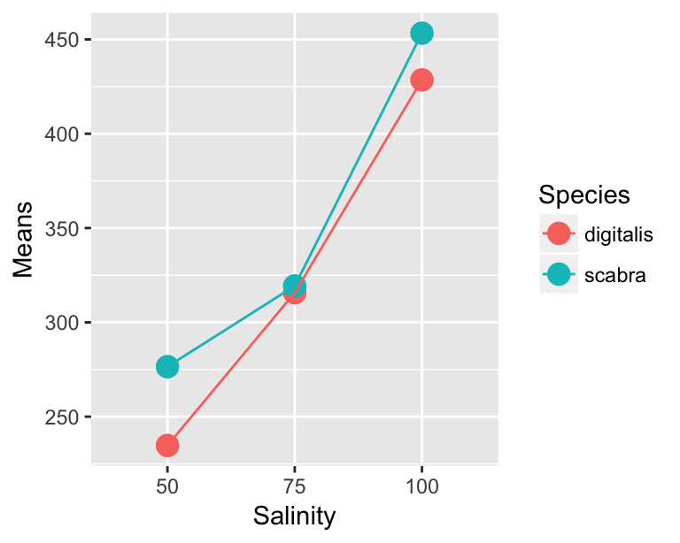

Once you are satisfied that you understand the relationships, fit a statistical model with `lm` that will allow you to address the three questions listed above. Once you have the fitted model object, use this to check the assumptions of your analysis.

**MOLE question**

What type of data are they?

**MOLE question**

Do the data satisfy the assumption of normality?

**MOLE question**

Are the variances similar among treatment combinations?

Next, carry out a statistical analysis to address the three questions above, and decide how to best summarise the results in written form.

**MOLE question**

What effects does the analysis indicate?

| Term | *F* | *d.f.* | *p* |
| --- | --- | --- | --- |
| Salinity effect: | ? | ? | ? |
| Species effect: | ? | ? | ? |
| Interaction: | ? | ? | ? |

**MOLE question**

Summarise the results from the ANOVA in words.

If you find any the global significance tests to be significant, it may be appropriate to carry out one, or more, multiple comparison tests. You should not carry out tests for any effects that are not significant (there’s no point in testing means you already know not to be different!).

**MOLE question**

If there were significant effects in the ANOVA summarise the differences between the means using a table of means with appropriate letter codes, and in words.

**MOLE question**

What does the analysis suggest about the osmoregulation of *Acmaea*.

Finally, see if you can prepare the following “publication quality” plot to summarise the results:

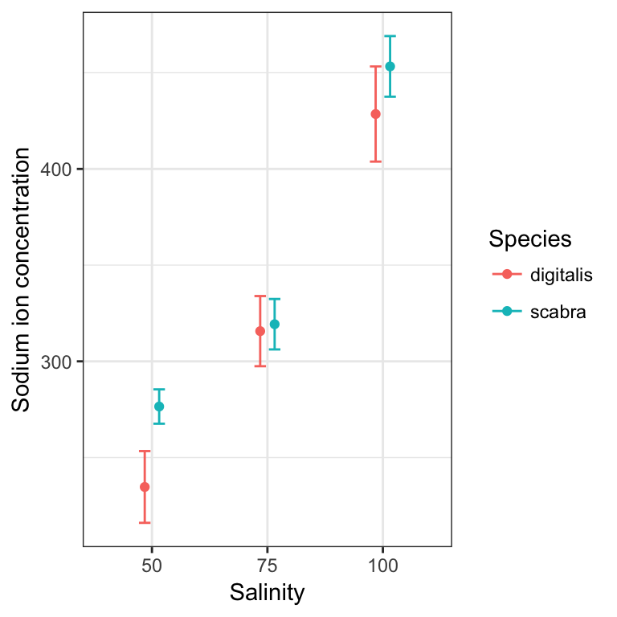

### Sheep, grass and nature reserves (again)

The aim of this exercise is to demonstrate that experimental design and statistical analysis are distinct activities. A particular design may be best served by a certain analysis, but there is often be more than one option available. A particularly clear example of this occurs when working with data from a paired-design experiment.

Take another look at the ‘Sheep, grass and nature reserves’ question from the Week 4. The experiment that produced these data is an example of a paired design—the variable of interest was species diversity in pairs of grazed and ungrazed plots.

The data were provided as a table. You used Excel to construct a ‘tidy’ version of the data set, which was then exported to a CSV file. If you kept the CSV file you can use this again here. If not, you’ll need to make the tidy CSV file again.

Once you have the CSV file, read the data it contains into R and use the `glimpse` function to understand what kind of variables you are working with. **Warning!** Pay close attention to the type of variable that R places in the `Plot` column. You may need to prepare the data for analysis first…

There is no need to visualise the data or check the assumptions again. You can skip these steps and jump straight into the statistical analysis. Do it two different ways:

1. Carry out a paired-sample *t*-test again using the `t.test` function.
2. Then carry out an ANOVA analysis using the `lm` and `anova` functions.

**MOLE question**

How similar are the results relating to grazing impacts from the two analyses?

**MOLE question**

What is the mathematical relationship between the *t*-statistic from the paired-sample *t*-test and the *F*-ratio for the treatment effect from the ANOVA?